# Outline / Brainstorm

# Introduction

In this primer we intend to demonstrate advantages of PLS over dimensionality reduction followed by univariate hypothesis testing, discuss model validation and hypothesis testing with PLS including important caveats, and demonstrate the use, reporting, and interpretation of PLS results on an ecological dataset.

# Questions I have

- What, if any, are the assumptions of PLS?
- How robust is it to departures from these assumptions?
- How exactly is Q<sup>2</sup> calculated? What is RMSE?
- What are the alternatives to permutation testing to get p-values. CV-ANOVA?
- What exatly is VIP? How is it related to the s-plot in SIMCA?

# Data sets:

1. cooked data, simple and small. (DONE)
2. cupcakes vs. muffins (DONE)
3. ecological data set(s) (search Dryad)
   - community composition?
   - pollination syndromes? (blanco pastor et al)
   - factors that predict species abundance? (like monarch data set)

# Methods (briefly)

## Simulated data methods

I generated a multivariate dataset with a random covariance structure. I am not sure how to “customize” this yet. Here’s the code:

```r
library(MASS)
library(dplyr)
vars = 50 #how many variables?
vars.diff = 5 #how many of the vars are going to contribute to differences between groups?
N = 20 #how many samples?
seed = 100
set.seed(seed)
A <- matrix(runif((vars)^2)*2-1, ncol=vars)
Sigma <- t(A) %*% A
data3 <- mvrnorm(n = N, mu = rep(0, vars), Sigma = Sigma) %>% as.data.frame()
```

I then assigned group membership for each row.

```r
data4 <- data3 %>%
  mutate(group = c(rep("a", nrow(data3)/2), rep("b", nrow(data3)/2))) %>%
  dplyr::select(group, everything())
```

Then I created a second data set that added 5 new variables that discriminated between groups

```r
set.seed(seed)
# add x variables that are based on existing ones but with differences between groups
x = 5
# strength of difference (passed to rnorm())
mu = 5
data5 <- data4 %>%
  mutate_at(vars(num_range("V", 1:x)),
            # if its in group a, add a random number, if group b, subtract a random number
            funs(D = ifelse(group == "a", . + rnorm(1, mu, 1), . - rnorm(1, mu, 1))))
```

Then I did PCA and PLS-DA on both datasets to produce the figure below. I tried this with several random seeds to purposefully cherry-pick an example where PCA reveals no separation, but PLS-DA is significant. I then did univariate t-tests for each variable to check that there were no differences just by chance in my totally random dataset.

## Cupcakes vs. Muffins methods

I took a random subsample of 40 recipes (20 muffins and 20 cupcakes) where each variable is an ingredient (in cups per serving) and applied PCA and PLS-DA on it. I tried this with several random seeds to purposefully cherry-pick an example where PCA revealed some separation to compare the results of PCA vs PLS-DA.

I should also do PLS regression on calories per serving and include that instead or in addition to the cupcakes vs. muffins plots.

# Results

## Simulated data set

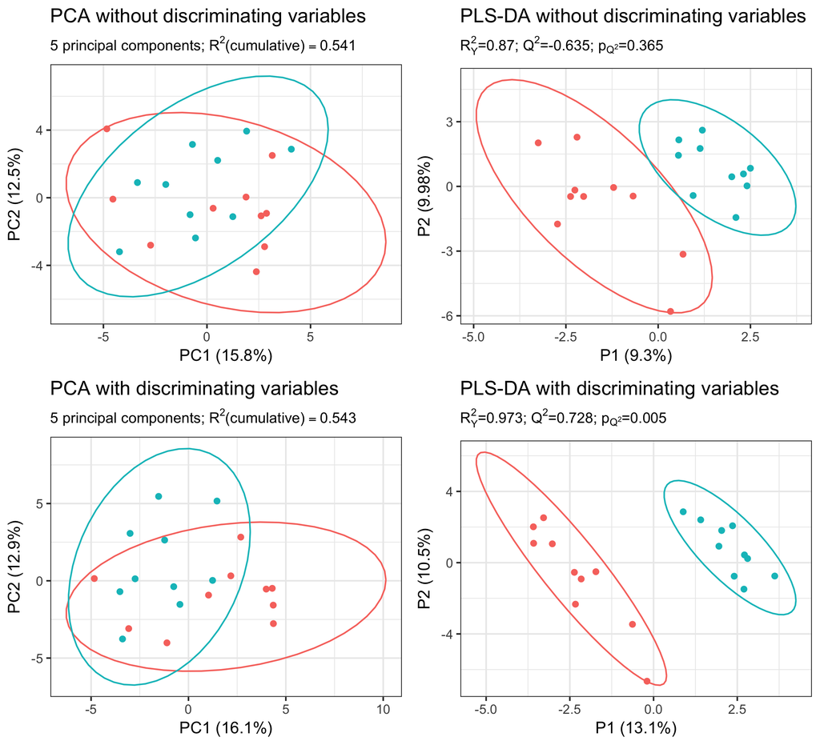

Figure 1: Multivariate analysis of simulated data with random group assignment (A, B) and with 5 aditional variables generated to discriminate between groups (C, D). For PCA plots (A, C), 5 prinicpal components were retained, and the first two principal components are plotted. For PLS-DA plots, the first two predictive axes are plotted, Q<sup>2</sup> values are calculated using 7-fold cross validation, and p<sub>Q<sup>2</sup></sub> is calculated with 200 permutations. Ellipses represent 95% confidence bounds, parenthetical numbers on axis labesl are the percent of total variation explained by the axis. Note, in figure B, the PLS-DA is clearly not a good model due to low Q<sup>2</sup> and a high p-value. We recommend not including a PLS-DA plot for non-significant results in a publication.

The addition of 5 discriminating variables has a negligible effect on the PCA. There is still essentially no separation between the two groups along either PC1 or PC2. However, the effect of these discriminating variables on the PLS-DA is apparent both in the visual separation between groups as well as the $Q^2$ and $p_{Q^2}$ values. The PLS-DA on completely random data also demonstrates the tendency of PLS to overfit. Without any cross-validation, one might conclude that the two groups were different, however the extremely low $Q^2$ and high p value from this model indicates that this separation is due to chance. Without reporting these cross-validation measures, the PLS-DA plot alone would be extremely misleading. We therefore recommend that plots of non-significant PLS models not be included in publications. It’s also worth noting that even though only 5 of 55 variables were created to distinguish the groups, the first predictive axis of the PLS-DA on the full data set describes 13.1% of the total variation in the data. In addition, the VIP scores of 5 non-discriminating varibles were over 1. Maybe VIP scores alone shouldn’t be used to determine importance of variables. False-discovery-rate adjusted t-tests more accurately identify distinguishing variables in this case.

## Cupcakes vs. Muffins

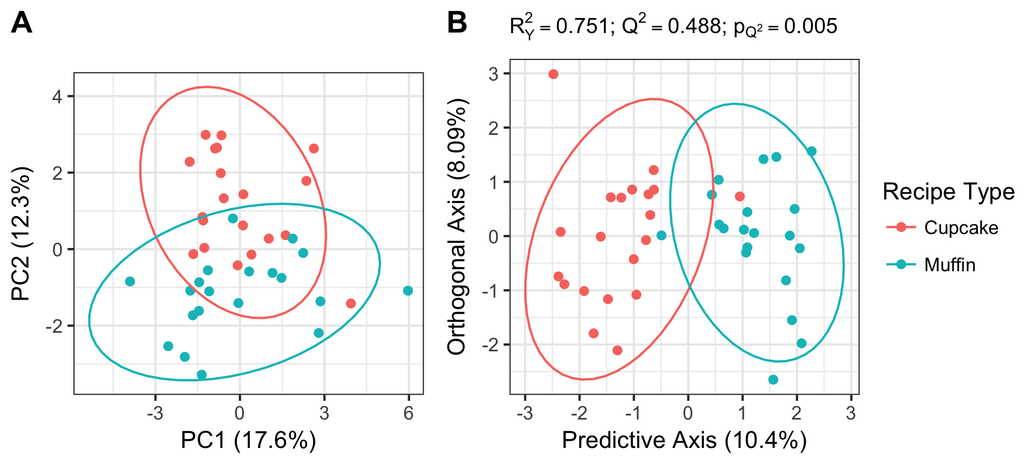

Figure 2: PCA (A) and PLS-DA (B) on 20 cupcake and 20 muffin recipes.

PCA and OPLS-DA both show some separation between cupcakes and muffins, but there are substantial differences in the two methods. First, although PC1 explains the greatest amount of covariation in the ingredients, it does not show any separation between cupcakes and muffins. PC2 shows some weak separation between cupcakes and muffins. This indicates that the variables with the greatest (co)variation in the dataset are not good predictors of the type of baked good. Even when comparing PC2, which separates cupcakes and muffins, with the OPLS-DA predictive axis, there are substantial differences. For example, “unitless” ingredients (e.g. “one sweet potato”, “25 blueberries”) are strongly negatively correlated with PC2 (toward muffins), however, it is not a good predictor of muffins vs. cupcakes as evidenced by its low VIP score and its weak correlation with the OPLS-DA predictive axis. Conversely, “spice” is a good predictor of muffins vs. cupcakes (muffins have more spices than cupcakes) as evidenced by a VIP greater than 1 and a stronger correlation with the OPLS-DA predictive axis, but have a weak correlation with PC2.

# Discussion

Discuss (mention?) variations on PLS and their advantages and disadvantages (PLS-DA, O-PLS, sPLS??, multi-level PLS for repeated measures).